[figure not shown]

March 2014, No. 1

# A Word from the Chair

Welcome to the first number of the new Virginia Math Bulletin! It is also my first year as Chair of the Mathematics Department. It has been an exciting year for me, and I still have a lot to learn about the position. My "learning-on-the-job" experience has been made easy because of the good advice and help I have received. I want to thank all of the faculty, staff, and students who have helped me this year, and particularly former Chairs Ira Herbst, John Imbrie, Brian Parshall, and Don Ramirez, Associate Chair Mikhail Ershov, and Graduate Directors Mike Hill and Tom Mark.

There have been many upbeat moments in the Department, which you can read about in this first newsletter. Here, I would like to preview some of the major events in the Department over the next few years. The single word that best describes what is happening is "change." Many distinguished faculty have retired or left to pursue new adventures. We will be hiring a large number of faculty over the next several years, and the type of department we become will depend greatly on the abilities and energy of the faculty we recruit. This year we welcomed two new tenure-track faculty: Andrew Obus and Ben Webster. We have recruited three new tenure-track faculty: Yen Do (coming in 2014-15), Thomas Koberda (coming in 2015-16), and Leonid Petrov (coming in 2014-15). We anticipate many more new faculty in the years to come.

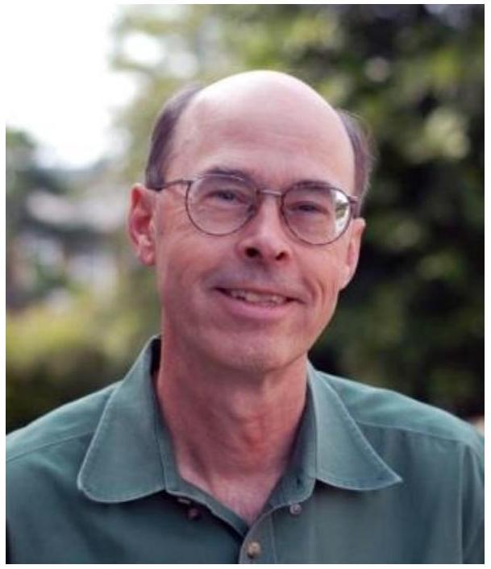

We welcome two new administrators, Zvezdana Kish, who came in 2012-13, and replaced Julia (Fay) Miller, as well as Teresa Taft, who started in 2014 and replaced Connie Abell. I am grateful for all their help. Luckily, Julie Riddleberger is still with us. She has served the Department for many years, and her institutional memory has saved us many times!

In May, there will be an external review of the Department. A committee of four distinguished mathematicians from other universities will give their advice about our department, which will help us improve. Next fall, we will also take a serious look at our undergraduate curriculum and how we teach it. Christian Gromoll will be leading our efforts at reform.

My coming to Virginia was enabled by an extremely generous gift from Mendel Rosenblum and Diane Greene. Mendel is the son of one of the past Chairs of the Mathematics Department, Marvin Rosenblum. Above all else, I would like to contribute to growing the UVa mathematics community of scholars, students, and friends. Whether you are a past major, graduate student, postdoc, or a friend, we’d love to hear from you.

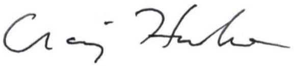

Craig Huneke  
Marvin Rosenblum Professor of Mathematics

## Supporting Us

The Mathematics Department is grateful for the generous support of its alumni and friends. The Department welcomes gifts annually to address its most urgent needs, as well as to the endowment which provides funding in perpetuity. To learn about how you can make a difference by supporting the Mathematics Department, please contact Liz Blaine at lblaine@virginia.edu or (434) 924-6156. To make a gift online, please visit http://giving.virginia.edu/mathematics

Department of Mathematics, University of Virginia, P. O. Box 400137, Charlottesville, VA 22904-4137  
www.math.virginia.edu

## New Faculty

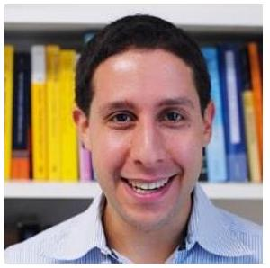

### Andrew Obus

*Assistant Professor*

Andrew Obus received his PhD in 2009 from the University of Pennsylvania, under the supervision of David Harbater. He then spent three years as an NSF postdoc at Columbia University under the supervision of Johan de Jong, as well as one year at the Max Planck Institute for Mathematics in Bonn. His research interests lie in arithmetic geometry, particularly those aspects related to Galois theory and fundamental groups of curves over arithmetically interesting rings and fields.

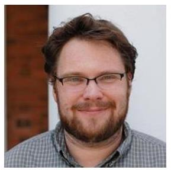

### Benjamin Webster

*Assistant Professor*

Ben Webster received his PhD in mathematics from the University of California, Berkeley in 2007; prior to coming to UVa, he held positions at Northeastern University, the University of Oregon, MIT, and the Institute for Advanced Study. His research interests connect the geometry of certain special singularities to representation theory, with applications in fields such as combinatorics and knot theory. While knots may seem like innocuous pieces of string, their modern study has proven important in biology, quantum computing, and other areas of mathematics. Tools from modern representation theory can shed new light on basic questions like when two knots are the same, and how difficult they are to untangle.

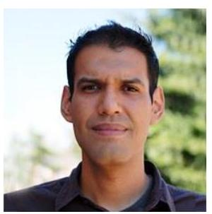

### Luis Núñez-Betancourt

*Whyburn Instructor*

Luis Núñez-Betancourt received his doctoral degree from the University of Michigan in 2013. He is originally from Mexico where he studied mathematics in the joint program of the University of Guanajuato and the Center for Mathematical

Research. Mr. Núñez-Betancourt works in commutative algebra and algebraic geometry, and his research is focused on local cohomology and the study of singularities in positive characteristic.

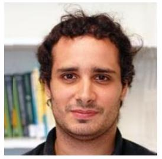

### Luis Pereira

*Mary Ann Pitts Post-Doctoral Fellow in Mathematics*

While in high school, Luis Pereira participated in the Mathematics Olympiads receiving gold medals in the Olimpiadas Portuguesas de Matemática in 2000, 2002, and 2003. He also participated in the International Mathematics Olympiads and in the Olimpiadas Iberoamericanas de Matemáticas in 2002 and 2003, obtaining a silver medal in the 2003 Olimpiadas. Mr. Pereira received his PhD in algebraic topology from MIT in 2013 under the supervision of Mark Behrens.

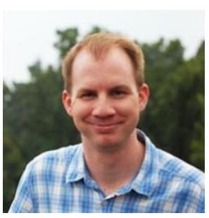

### Christopher Ramsey

*NSERC Postdoctoral Fellow*

In 2013, Christopher Ramsey received his PhD from the University of Waterloo, in Waterloo, Ontario, under the supervision of Professor Ken Davidson. His research interests are in operator algebras and multivariable operator theory.

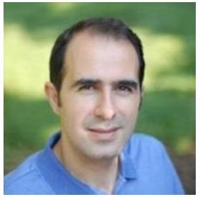

### Bulent Tosun

*Whyburn Instructor*

Bulent Tosun was born and raised in Turkey. In 2012, he received his PhD in mathematics from the Georgia Institute of Technology under the supervision of Professor John Etnyre. He was a postdoctoral fellow at Centre de recherches mathématiques in Montreal, Canada from 2012-2013, working with Professors Steven Boyer and Olivier Collin. During his stay in Montreal, he taught at McGill University. Tosun’s research is in the areas of geometry and topology of low-dimensional manifolds and symplectic and contact topology.

## New Graduate Students

John Berman  
Kristin Courtney  
Bradley Dorner  
Mariano Echeverria  
Matthew Gagne  
Gabriel Islambouli  
James Phillips III  
Eloisa Pires  
Michael Reeks  
Brian Thomas  
Robert Williams

## News and Events

### Professors to Speak at ICM Meeting

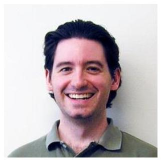

#### Michael Hill

*Associate Professor*

Michael Hill will be giving an invited address at the International Congress of Mathematicians being held in Seoul, Korea, in August 2014. He will be reporting on his work with collaborators, Harvard Professor Michael Hopkins and Rochester Professor Douglas Ravenel, solving the “Kervaire Invariant One Problem.” This 50-year-old problem was one of the most famous open problems in geometric topology and algebraic topology.

Geometric topology concerns itself with the study of geometric objects like curves, surfaces, and their higher dimensional analogues called manifolds. Algebraic topology is the study of algebraic invariants of such geometric objects: One is trying to capture the world of geometry through its reflection in the more rigid world of algebra.

In the 1950’s and 60’s, there was a lot of work done towards classifying manifolds using methods from differential topology, the study of large-scale geometric structure using multivariable calculus. Rather remarkably, the methods worked best when studying manifolds that were at least $5$ dimensional, and manifolds with striking exotic properties were discovered beginning in dimension $7$. A big push towards classifying a natural family—“framed” manifolds—led to an ambiguity in dimensions $2$ less than a power of $2$. In a rather clever way, one assigns a number equal to $0$ or $1$, to a framed manifold in these dimensions. An ordinary sphere has Kervaire invariant $0$, and the open question was whether or not there were exotic manifolds with invariant $1$. By the late 1960’s this fundamental problem in geometric topology had been translated into a fundamental problem in algebraic topology, and it resisted attack for the next 40 years. At a conference in Edinburgh, Scotland, in April 2009, Hill and his collaborators announced that the conjectural exotic manifolds do NOT exist beginning in dimension $254$, in contrast to earlier positive results in dimensions $2, 6, 14, 30, 62$. The $126$-dimensional case is still open, so there is a nice question still to be resolved by those who are good at visualizing framed $126$-dimensional manifolds!

Though the methods used in the proof are very much those of the 21st century, they heavily use two classic areas within algebraic topology: cobordism theory—the study of how a manifold might be the boundary of a higher dimensional manifold, and equivariant topology—the study of how groups can act as symmetries of geometric objects. These two areas of algebraic topology have long associations with the UVa Mathematics Department, beginning with the work in the 1950’s and 60’s of Professors Pierre Conner and Ed Floyd, and continuing today with the work of Professors Greg Arone, Michael Hill, and Nicholas Kuhn.

The Hill–Hopkins–Ravenel Theorem has attracted much international attention, including being the focus of many conferences held around the world. It was the topic of articles in *Nature* and *Scientific American*. Hill, who received his Ph.D. from MIT in 2006 and was a Whyburn postdoctoral instructor with us in 2009, was awarded a prestigious Sloan

Foundation Fellowship in 2011. Co-author Hopkins was elected to the National Academy of Sciences in 2010, and in 2012 was awarded the NAS Prize for Mathematics. Hill’s current research is focused on reworking the foundations of equivariant stable homotopy, and in spring 2014, he is one of the organizers of an algebraic topology emphasis semester at the Mathematical Sciences Research Institute in Berkeley.

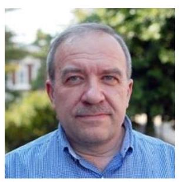

#### Andrei Rapinchuk

*Professor*

The invitation of Andrei Rapinchuk to speak at the ICM-2014 in Seoul resulted from a series of recent papers in the area of algebraic groups written with Gopal Prasad (University of Michigan) and other co-authors. These papers mostly use algebraic methods from group theory and number theory, but have remarkable applications to other areas, primarily differential geometry.

Algebraic groups can be defined as groups of matrices whose entries satisfy systems of polynomial equations—a simple example of such a group is $\operatorname{SL}_{n}(\mathbb{R})$, the group of $n \times n$ matrices with real entries whose determinant is equal to $1$. Rapinchuk and his co-authors developed new techniques for analyzing Zariski-dense subgroups of simple algebraic groups; informally, a subgroup is called Zariski-dense if it is big enough in the sense that all polynomial equations that hold identically for the elements of the subgroup must also hold for the entire group.

These techniques enabled Prasad and Rapinchuk to make an important progress on the famous question: “Can one hear the shape of a drum?” The precise mathematical formulation of this question deals with the special differential operator on a compact Riemannian manifold known as the Laplace–Beltrami operator. Riemannian manifolds are certain spaces in which one has the notion of arclength and angles between curves satisfying familiar properties (for instance, a sphere or a torus are examples of two-dimensional compact Riemannian manifolds), and the Laplace–

Beltrami operator is defined in pretty much the same way as the Laplacian in multivariable calculus. For over a century, mathematicians have been interested in the question of whether the spectrum (the set of eigenvalues) of the Laplace–Beltrami operator actually determines the manifold up to isometry (that is, up to a distance-preserving bijection). Note that from the physical viewpoint, the eigenvalues that make up the spectrum determine the frequencies present in the “sound” produced by the “drum” shaped as the manifold at hand, hence the informal formulation about “hearing the shape.”

The important analytic result known as Weyl’s Law (established in 1911) tells us that the spectrum indeed determines the dimension, volume and other characteristics of the manifold, strongly suggesting that the manifolds with the same spectrum (called isospectral) should be expected to be isometric. This expectation was refuted by a general construction proposed by Sunada in 1985. It should be noted however that Sunada’s construction always produces manifolds, which, while non-isometric, are commensurable (informally, this means that one manifold can be obtained from the other by cutting the latter into pieces and re-assembling those pieces). This suggested that the “right” conjecture should call not for the isometricity, but rather for commensurability, of isospectral manifolds. In fact, this modified conjecture also turned out to be false in the general case (Lubotzky, et al.), but at the same time it was proved to be true for some classes of Riemannian manifolds in dimensions $2$ and $3$ (Reid, et al.).

Until the work of Prasad and Rapinchuk, these were the only cases where the conjecture was known to have the positive answer. In a paper published in the highly prestigious journal Publications Mathématiques de l’IHES, they proved the conjecture for a large class of spaces. Their research has generated a number of new problems in such areas as the theory of central simple algebras, algebraic and Lie groups, and Galois cohomology. Part of Rapinchuk’s address will be devoted to the precise formulations of conjectures in these new directions of research.

## Mary Ann Pitts Post-Doctoral Fellowship in Mathematics

*Spotlight on Our Mary Ann Pitts Post-Doctoral Fellow*

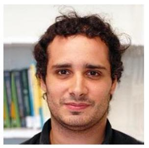

The Department is very grateful for the gift of Rob Pitts (class of 1986) to endow a new instructorship in mathematics, the Mary Ann Pitts Post-Doctoral Fellowship in Mathematics, in honor of his mother, Mary Ann Pitts, a long-time teacher of mathematics. After graduating from UVa, Rob went to Harvard Business School and has had a successful career in business. We are proud to have hired Luis Pereira as our first Mary Ann Pitts Post-Doctoral Fellow.

Luís Alexandre Pereira earned his bachelor and master degrees at Instituto Superior Técnico in Portugal. He received his PhD in mathematics from MIT in 2013. His thesis advisor was Mark Behrens, and his area of specialization is algebraic topology. This field of mathematics is a meeting ground between algebra (study of symmetries) and topology (study of generalized geometric shapes). In the early years of the subject, algebraic topologists mostly used tools from algebra to gain insight into topology. More recently, their focus shifted toward combining topology with other fields of mathematics. For example, in the past decades there has been much study of certain generalizations of Abelian groups and rings inspired by topology. Topologists call these generalized objects "infinite loop spaces" and "ring spectra." Pereira’s thesis deals with natural constructions involving these objects. He has shown that certain constructions can be interpreted as a kind of generalized "Taylor series." The analogy with Taylor series is striking. It was first conceived of by Tom Goodwillie, in the more restricted context of topological spaces. This circle of ideas is now known as the calculus of functors. Among other things, Pereira is interested in extending further the context in which the calculus of functors applies.

We have a long, distinguished tradition of algebraic topology, going back to the days of P. E. Conner and E. E. Floyd. We are happy to welcome Pereira into the Department.

## Faculty Awards

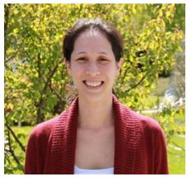

### Tai Melcher

*Assistant Professor*

Tai Melcher received the Association for Women in Mathematics Service Award at a ceremony in January. This award recognizes individuals for helping to promote and support women in mathematics through exceptional voluntary service to the Association for Women in Mathematics. Tai was cited both for her service to the AWM as a PI on a successful NSF grant, and for her involvement in the organization of AWM activities at the USASEF festival.

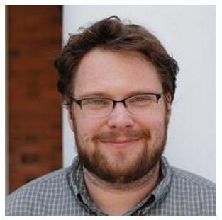

### Ben Webster

*Assistant Professor*

Ben Webster won an Alfred P. Sloan Research Foundation Fellowship for 2014. Awarded annually since 1955, Sloan Fellowships are given to early-career scientists and scholars whose achievements and potential identify them as rising stars—the next generation of scientific leaders with capacity for substantially contributing to and possibly changing their fields. See UVa Today.

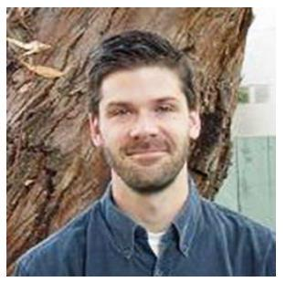

### David Sherman

*Associate Professor*

Department of Mathematics faculty member David Sherman has been promoted to Associate Professor effective August 2013. In 2013, he also won the Cory Family Teaching Award, a new prize presented annually to two assistant professors in the College of Arts and Sciences, recognizing excellence in undergraduate instruction.

David did his undergraduate work in mathematics and Russian at Washington University in St. Louis, and took his PhD at UCLA in 2001 under the direction of Masamichi Takesaki. He subsequently held postdoctoral appointments at the University of Illinois and the University of California-Santa Barbara, and he joined the UVa faculty in  
2007. David works primarily in functional analysis and operator algebras, especially von Neumann algebras, a subject that began with the seminal work of Murray and von Neumann in the 1920’s when operators on Hilbert space (the natural infinite-dimensional analog of Euclidean space) were coming to be understood as the right model for physical observables in quantum mechanics. Present-day operator algebras relates to many branches of mathematics, offering noncommutative generalizations of geometry, topology, and probability, among other things. David’s current research includes non-commutative convexity and surprising connections with logic.

On the teaching side, David created and has offered the January Term course MATH 2700 (Euclidean and Non-Euclidean Geometry) regularly since 2008 (this is the only math course ever offered during January Term), and effectively developed MATH 3000 (Transition to Higher Mathematics) as a new course. He directed the doctoral work of Craig Kleski (PhD 2013, currently at Miami of Ohio) and is presently supervising PhD research for Scott Atkinson and Stephen Hardy.

With great zeal but fewer credentials, he also supervises his three children: Talia 11, Benjamin 8, and Sadie 4.

## Student Awards

### Edwin E. Floyd Prize in Mathematics

April 26, 2013

The 2013 Edwin E. Floyd Prize in Mathematics was given to Ahsan Khan and Calvin McPhail-Snyder. The prize is awarded to second- or third-year students who show exceptional promise in mathematics.

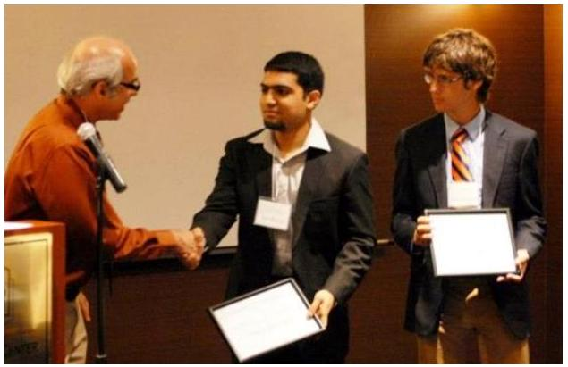

### E. J. McShane Prize in Mathematics

April 26, 2013

The 2013 E. J. McShane Prize in Mathematics was given to graduating $4^{\text {th }}$-year students Casey Mihaloew, Fei Song, and Sittipong Thamrongpairoj for their achievements in mathematics.

[figure not shown]

### William Lowell Putnam Mathematical Competition Award

April 26, 2013

The 2013 William Lowell Putnam Mathematical Competition Award was given to Fei Song for her outstanding score on the exam. Congratulations to the entire team, Christopher Olund, Fei Song, and Sittipong Thamrongpairoj. The team ranked $15{ }^{\text {th }}$ of 402.

### Ajay Chandra Wins TRC Teaching Award

April 18, 2013

Graduate student Ajay Chandra won the Teaching Resource Center’s Graduate Teaching Assistant Award in Mathematics for 2013.

### Tim Emerick and Carolyn Yarnall Receive Teaching Award Honorable Mention

May 3, 2013

Timothy Emerick and Carolyn Yarnall received graduate teaching award honorable mention for 2013.

## Putnam Competition

In this event, undergraduates from North America compete in a two-part mathematical exam lasting a total of six hours. Scoring well in this competition is extremely difficult, with the median score each year being less than 1 out of 120 points possible! There are significant cash awards associated with the competition, and the top ten individual scores get tuition waived to attend Harvard University.

Over the last several years, our undergraduates, coached by our postdoctoral instructors, have performed exceptionally well. In both 2008 and 2009, one of our undergraduates, Wuttisak Trongsiriwat, placed in the top 60. In 2011, Casey Mihaloew placed in the top 80. Fei Song placed $22^{\text{nd}}$, and received the Elizabeth Lowell Putnam Prize awarded to the top woman competitor.

[figure not shown]

David Hill (Whyburn Instructor) and Fei Song (our Putnam winner)

While any undergraduate may participate in the Putnam exam, each department also chooses three individuals to represent their university in a team competition. In 2009, our team placed $8^{\text{th}}$ thanks to the performance of Wuttisak Trongsiriwat, Fei Song, and Casey Mihaloew. In 2010, Fei Song, Sittipong Thamrongpairoj, and Casey Mihaloew placed $22^{\text{nd}}$. In 2011, Fei Song, Casey Mihaloew, and Chris Olund placed $7^{\text{th}}$. During last year’s 2012 competition, Fei Song, Sittipong Thamrongpairoj, and Chris Olund placed $15^{\text{th}}$ overall.

## Retirements

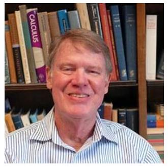

### Thomas Kriete

*Professor*

Retiring this summer, Tom Kriete did both his undergraduate and graduate work at the University of Virginia, receiving his PhD in 1968 as a student of Marvin Rosenblum. After a brief appointment at the University of Miami, he returned to UVa, joining the Mathematics Department in 1969.

Tom’s research is about operators on Hilbert space. Highlights of his work include the proof of subnormality of the Cesàro operator (with David Trutt), characterization of composition operators having subnormal adjoint (with Carl Cowen), determination of the spectral multiplicity of multiplication operators (with Bruce Abrahamse), development of the theory of composition operators on large weighted Bergman spaces (with Barbara MacCluer), and his collaboration with MacCluer and former student Jennifer Moorhouse on the structure of $\mathrm{C}^{*}$-algebras generated by composition and Toeplitz operators on the Hardy space.

He has been a superb director of doctoral students, advising a total of 12 PhD students. Tom is a gifted teacher at both the graduate and undergraduate level, and he was in demand as an undergraduate advisor. His advising duties include decades of Echols advising, a task he particularly enjoyed as he himself had been in the first class of Echols scholars. He initiated the Distinguished Major Program in mathematics, and served for many years as Chair of the Upper Division Committee.

With colleagues Barbara MacCluer and Paul Bourdon, Tom is currently writing an undergraduate text on differential equations, and he has used versions of this book to direct self-study courses for area high school students.

In retirement, Tom is looking forward to completing this book project, continuing to do mathematics research, playing guitar, and increasing his swimming regimen.

## Recent PhDs

### May 2013

**Constance Baltera** (Advisor: Weiqiang Wang)  
*Coinvariant Algebras and Fake Degrees*

**Daniel Dobbs** (Advisor: Tai Melcher)  
Asst. Professor, Huntington University  
*Properties of Measures and Processes Related to Brownian Motion on Infinite-Dimensional Heisenberg-Like Groups*

**Sean Droms** (Advisor: Tom Mark)  
Asst. Professor, Lebanon Valley College  
*Constructions of Stein Fillings*

**Timothy Emerick** (Advisor: Peter Abramenko)  
Systems Engineer, CCRi  
*A Group-Theoretic Characterization of the Unipotent Radical*

**Craig Kleski** (Advisor: David Sherman)  
Visiting Asst. Professor, Miami University  
*Boundaries for Operator Systems*

**Kristen Mazur** (Advisor: Michael Hill)  
Visiting Asst. Professor, Lafayette College  
*On the Structure of Mackey Functors and Tambara Functors*

**Timothy Pollio** (Advisor: Andrei Rapinchuk)  
Instructor, University of Virginia  
*The Multinorm Principle*

**Carolyn Yarnall** (Advisor: Michael Hill)  
Visiting Asst. Professor, Wabash College  
*The Slices of Suspensions of $HZ$ for Cyclic $p$-Groups*

### August 2013

**Nicolas Fourrier** (Advisor: Irena Lasiecka)  
Research Analyst, CGG  
*Analysis of Existence, Regularity, and Stability of Solutions to Wave Equations with Dynamic Boundary Conditions*

**Andrea Merlin Heald** (Advisor: Andrei Rapinchuk)  
*Bounded Generation of Two Families of $S$-Arithmetic Groups*

**Matthew Hogancamp** (Advisor: Slava Krushkal)  
Visiting Asst. Professor, Indiana University  
*Local and Quasi-Local $\mathfrak{sl}(2)$ Link Homology*

### December 2013

**Mor Katz** (Advisor: Thomas Kriete)  
*Essentially Normal Composition Operators*

## The Problem Corner

**Easiest:** Is there a function $f$ from the positive integers to the positive integers such that $f(f(n)) = n+1$ for all $n$?

**A Little Harder:** The sum of all the digits of a fixed number $N$ is the same as the sum of the digits of the number $2N$. Show that $N$ is divisible by $9$.

**Harder:** Show that the set of natural numbers which cannot be expressed as a sum of at least two consecutive positive integers is exactly the set of all powers of $2$. (For example, $12 = 3+4+5$ is not in the set.)

**Hardest:** Two numbers $a$ and $b$ are between $2$ and $99$. Peter is given the product of the numbers, $ab$ (and knows he is given the product). Sarah is given the sum $a+b$ (and knows she is given the sum). They also know the numbers are between $2$ and $99$. They are UVa math majors, so they are great at math and completely honorable!

Peter says, "I don’t know the numbers."  
Sarah says, "I knew you didn’t know the numbers."  
Peter then says, "I know the numbers now."  
Sarah then says, "Ah ha! I know the numbers now."

What are the numbers?

## What Are You Doing?

We’d like to hear from you!  
You may complete the form below and return it to us:

Form (ctrl+click):  
http://pi.math.virginia.edu/questionnaire.pdf

FAX: 434-982-3084  
Email: math-help@virginia.edu  
Department of Mathematics  
University of Virginia  
P. O. Box 400137

Charlottesville, VA 22904-4137